# Portfolio Website Project Proposal

A data-driven portfolio for a career in beauty marketing

Author

Julieta Diaz

Published

October 26, 2026

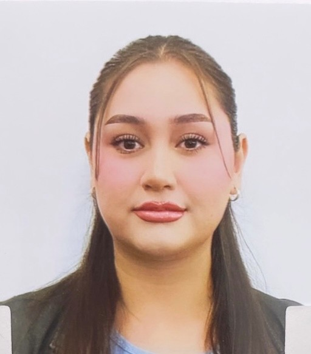

Hi, I’m Julieta

Here is the plan for my MSDM portfolio website

[See the current site](https://jukedz.github.io/msdm-portfolio/) [View the GitHub repo](https://github.com/jukedz/msdm-portfolio)

# Executive Summary

My portfolio website will show hiring managers in the **beauty industry** that I can turn consumer data into marketing decisions. It will have four tabs: **Home**, **Digital Marketing Projects**, **Marketing Analytics Projects**, and **Resume**. Each project page will follow the structure of a typical analytics report: the business problem, the data, the research questions, the methods, the results, and the recommendations.

**TipAt a glance**

# 1 Website Structure

## 1.1 Site Map

```
flowchart LR
  H[Home] --> D[Digital Marketing Projects]
  H --> M[Marketing Analytics Projects]
  H --> R[Resume]
  D --> D1[DM1: Google Shopping Ads Plan]
  D --> D2[DM2: Juke Vintage E-commerce Store]
  D --> D3[DM3: Golf Performance Lab Plan]
  M --> M1[MA1: Paid vs. Organic Search]
  M --> M2[MA2: Portfolio Website Traffic in GA4]
  M --> M3[MA3: Revealjs Insights Presentation]
  M --> M4[MA4: Influencer vs. Traditional Ad Experiment]
```

Figure 1: Planned site map for the portfolio website

## 1.2 Tabs and How They Will Be Built

Table 1: Planned tabs on the portfolio website

| Tab | Purpose | How it will be built in Quarto |
| --- | --- | --- |
| Home | Introduce me, my goals, skills, and education | Custom hero layout, skill pills, education timeline |
| Digital Marketing Projects | Show campaign planning and e-commerce work | A grid **listing** of project pages, filtered by category |
| Marketing Analytics Projects | Show data analysis, dashboards, and presentations | A grid **listing** of project pages, including the GA4 traffic analysis and the Revealjs deck |
| Resume | Summarize my experience in a recruiter-friendly format | A resume page plus a downloadable PDF built with the `vitae` R package |

**NoteChanges from my current site**

The current site (built for M10 Hands-on Practice) has Home, CEP Dashboard, Styling with SCSS, and Portfolio Listings tabs. For the final version, the CEP dashboard moves into **Marketing Analytics Projects**, the listings feature powers both project tabs, the SCSS styling stays in place behind the scenes, and a **Resume** tab is added.

# 2 Home Page

The home page is already live and will be refined over the term.

Table 2: Home page contents

| Element | Plan |
| --- | --- |
| Photo and intro | A “Hi, I’m Julieta Diaz” banner with my photo in a polaroid-style frame |
| Bio | Psychology background, MSDM training, public sector work, and my vintage resale shop, Juke Vintage |
| Career aspirations | Transition into the beauty industry and grow into a data-driven marketing leadership role |
| Skills | R, Quarto, SQL, BigQuery, GA4, Google Ads, Qualtrics, Shopify, GitHub, Canva |
| Education | MSDM, Cal Poly Pomona (expected Summer 2027); Bachelor’s in Psychology, CSU San Bernardino (2021) |
| Call to action | Buttons linking to my projects, my resume, and LinkedIn |

# 3 Digital Marketing Projects

Each project below will become its own page under the **Digital Marketing Projects** tab.

Table 3: Digital marketing projects overview

| # | Project | Data and source | Audience |
| --- | --- | --- | --- |
| DM1 | Google Shopping Ads Plan for CPP Farm Store Gift Baskets | Farm Store product catalog, Google Ads coursework, competitor research | Farm Store manager |
| DM2 | Juke Vintage E-commerce Store and Customer Journey | My Shopify store, GA4 property, Depop inventory | Small fashion resale owners |
| DM3 | Digital Marketing Plan for Golf Performance Lab | Client presentation, client and competitor websites | Golf Performance Lab owner |

## 3.1 DM1: Google Shopping Ads Plan for CPP Farm Store Gift Baskets

[output not shown]

## 3.2 DM2: Juke Vintage E-commerce Store and Customer Journey

| Element | Plan |
| --- | --- |
| **Data and source** | My Juke Vintage Shopify store (catalog, collections, checkout settings), its GA4 property, and my Depop sales inventory |
| **Managerial problem** | A one-person resale shop needs a trustworthy, easy-to-shop storefront that turns browsers into buyers |
| **Target audience** | Small fashion and resale business owners (and me, as the owner) |
| **Research questions** | (1) Where in the customer journey do shoppers drop off? (2) Which trust signals and merchandising choices make the store feel credible? (3) What should the owner track in GA4? |
| **Expected impact** | A clearer customer journey, stronger trust signals at checkout, and a measurement plan for future sales growth |
| **Methods** | Customer journey mapping, merchandising and storefront audit, GA4 setup and event tracking, and funnel analysis of the realtime and engagement reports |

## 3.3 DM3: Digital Marketing Plan for Golf Performance Lab

| Element | Plan |
| --- | --- |
| **Data and source** | Client presentation (Dr. Michelle Yoo), the client website, and competitor websites |
| **Managerial problem** | An indoor golf instruction facility in Los Angeles needs more foot traffic and digital traffic |
| **Target audience** | Golf Performance Lab owner |
| **Research questions** | (1) Who are the facility’s most valuable customer segments? (2) How does it compare with local competitors online? (3) Which channels and messages will grow traffic most efficiently? |
| **Expected impact** | A multi-part digital marketing plan with clear priorities for channels, content, and measurement |
| **Methods** | Company overview, market and competitor analysis, SWOT, segmentation and targeting, channel strategy, and a KPI dashboard plan (group project with Danielle Meza, Cecilia Espina, and Georgia Monjarrez) |

# 4 Marketing Analytics Projects

Each project below will become its own page under the **Marketing Analytics Projects** tab. As required, the website traffic analysis (MA2) and the Revealjs presentation (MA3) are listed here as projects rather than as separate tabs.

Table 4: Marketing analytics projects overview

| # | Project | Data and source | Audience |
| --- | --- | --- | --- |
| MA1 | Paid vs. Organic Search for the CPP Farm Store | GA4 e-commerce data via BigQuery (Farm Store data when available) | Farm Store manager |
| MA2 | Portfolio Website Traffic Analysis in GA4 | GA4 property installed on this website | Me, as owner of my personal brand |
| MA3 | Revealjs Insights Presentation | Results from MA1 | CEP client and faculty lead |
| MA4 | Influencer vs. Traditional Ad Experiment | Qualtrics survey with random assignment | Brand marketing manager |

## 4.1 MA1: Paid vs. Organic Search for the CPP Farm Store

[output not shown]

**NoteEarly result on sample data**

In the GA4 sample store, paid search converted at about 0.98% vs. 1.18% for organic search (chi-square = 4.55, p = .033). This is already shown in the [CEP dashboard](https://jukedz.github.io/msdm-portfolio/cep-dashboard.html) on my current site.

## 4.2 MA2: Portfolio Website Traffic Analysis in GA4

[output not shown]

**WarningData limitation**

A new portfolio site will have a small number of visitors, so results will be descriptive and directional rather than conclusive. I will report sample sizes alongside every finding.

## 4.3 MA3: Revealjs Insights Presentation

[output not shown]

## 4.4 MA4: Influencer vs. Traditional Ad Experiment

| Element | Plan |
| --- | --- |
| **Data and source** | A Qualtrics survey experiment I designed in IBM 6500, in which respondents are randomly assigned to see either a social media opinion leader review or a traditional ad for a Nike product |
| **Managerial problem** | Brands are shifting budget toward influencers, but they need evidence that influencer content actually lifts purchase intention compared with traditional ads |
| **Target audience** | Brand marketing manager deciding how to split budget between influencer and traditional advertising |
| **Research questions** | (1) Does ad type affect purchase intention and attitude toward the brand? (2) Does social media usage moderate the effect? |
| **Expected impact** | Guidance on when influencer content is worth the investment, which transfers directly to beauty brands, where influencer marketing is central |
| **Methods** | Randomized experiment, reliability analysis (Cronbach’s alpha) for multi-item scales, independent-samples t-test, two-way ANOVA for the moderation question, and data wrangling in R |

# 5 Resume

My current resume (2025) is written for social services and public sector roles. For the portfolio, I will rebuild it for **digital marketing and marketing analytics** roles, keeping my real experience but reframing it around the skills beauty brands hire for.

Table 5: Resume plan

[output not shown]

**NoteReframing my experience for marketing**

Table 6: How my current experience translates to marketing

| Current experience | Marketing-relevant skill it shows |
| --- | --- |
| Reviewing vendor proposals and running RFPs | Evaluating partners and agencies with clear criteria |
| Preparing reports and summaries for board approvals | Turning data into clear recommendations for decision makers |
| Tracking deliverables and vendor performance in databases | KPI tracking and performance measurement |
| Building data collection systems for IEP goals | Designing measurement plans and analyzing progress data |
| Leading group conversations and serving as a Spanish interpreter | Understanding diverse audiences and bilingual communication |

**WarningPrivacy on a public website**

The online version will list only my email, LinkedIn, and GitHub. My home address and phone number will stay off the public site and appear only on PDFs I send directly to employers.

# 6 Timeline

Table 7: Planned timeline

| Week | Milestone |
| --- | --- |
| Week 10 | Proposal submitted; home page and site structure live |
| Weeks 11 to 12 | Build the Digital Marketing Projects listing and pages (DM1 to DM3); add the GA4 tag for MA2 |
| Weeks 13 to 14 | Build the Marketing Analytics Projects pages (MA1, MA3, MA4); collect MA2 traffic data |
| Week 15 | Add the resume page and PDF; analyze MA2 traffic data |
| Final | Polish, proofread, test all links, and publish the final website |

# Next Steps

1. Restructure the navbar into Home, Digital Marketing Projects, Marketing Analytics Projects, and Resume.
2. Add the GA4 tracking tag to `_quarto.yml` so MA2 starts collecting data right away.
3. Swap Farm Store GA4 data into MA1 if access is granted; otherwise keep the sample data, clearly labeled.
4. Build each project page using the same analytics report structure: problem, data, research questions, methods, results, and recommendations.

# Appendix: Links

**This proposal**

- [This proposal on GitHub Pages](https://jukedz.github.io/ibm6500-assignments/M10-Portfolio-Proposal/portfolio-website-proposal.html)
- [This proposal’s source folder on GitHub](https://github.com/jukedz/ibm6500-assignments/tree/main/M10-Portfolio-Proposal)

**My portfolio website**

- [Current website](https://jukedz.github.io/msdm-portfolio/)
- [Website GitHub repository](https://github.com/jukedz/msdm-portfolio)